# FH models, Anemia

SAE Estimators

[Angelo Cozzubo] (https://sites.google.com/pucp.pe/acozz)

This R Markdown file computes the Small Area Estimation (SAE) results for Anemia in Peru at the provincial level. Our project is conducted as part of the 2022 Venture Fund awarded to our project “Exploiting Data to its fullest: Machine Learning and Small Area Estimation” (code LABO.10.35). We are grateful to NORC for this award and to the National Statistical Office in Peru, INEI, for sharing their public and non-public datasets with us to carry on with our application. Any potential remaining errors are my own.

## 0. Preliminaries

First, we start loading (and installing if required) the packages we will be using.

```r
set.seed(123)
# install and load the packages
pacman::p_load(sae, haven, tidyverse, ggpubr,
               labelled, survey, dplyr, moments,
               caret, sf, tmap, spdep, rgdal, StepReg,
               sparsepca, emdi, maptools, gpclib, SAEval,
               glmmLasso, rospca, readxl, writexl)
gpclibPermit()
```

```
## [1] TRUE
```

We set the working directory and specific routes.

```r
setwd("C:\\Users\\cozzubo-angelo\\OneDrive - National Opinion Research Center\\VF_SAEML\\")

# paths
wd <- file.path("C:\\Users\\cozzubo-angelo\\OneDrive - National Opinion Research Center\\VF_SAEML\\")
scripts <- file.path("02_scripts\\FH\\")
data <- file.path("03_data\\")
outputs <- file.path("04_results\\")
```

Connect to user-written functions available in the script `my_fns.R`: SpatialFH, choropleths

```r
source(paste(scripts,"my_fns.R", sep="\\"))
```

And we load the datasets that are in Stata format (.dta)

```r
endes <- read_dta(paste(data, "original", "ENDES_TOT.dta", sep="\\"))
var_labels <- var_label(endes)
tot_pob_prov <- read_dta(paste(data, "covariates", "censo2017_tot_pob_prov.dta", sep="\\"))
```

And declare sampling design of the survey to later compute the direct estimates. We are using the pooled DHS dataset (Endes) for the years 2017-2019. This is a survey with complex design (stratified, multiple selection stages, etc.) and contains all the required information to declare the design and compute weighted estimators (sampling weights).

```r
endes <- transform(endes,
                   ID_UBICONG = as.numeric(ID_UBICONG),
                   ID_NINIO = as.numeric(ID_NINIO))
dclus2 <- svydesign(id=endes$ID_UBICONG+endes$ID_NINIO,
                    strata=endes$HV022, nest=TRUE,
                    weights = endes$FACTOR_NINIO_2,
                    data=endes)
```

## 1. Direct estimates from survey data

First, we compute the total sample size, number of domains (in our case, provinces), sample size in each province and population totals from Census data. We drop province 1608 as it was not included in the survey data and province 209 as it does not have any case of anemia (variance = 0).

```r
n <- dim(endes)[1] # Tamaño muestral total
D <- length(unique(endes$ID_PROV)) # Número de provincias (áreas o dominios)
nd <- as.vector(table(endes$ID_PROV)) # Tamaños muestrales de las provincias

#this provinces is dropped below.
nd_ <- as.vector(table(endes[!(endes$ID_PROV=="209"),]$ID_PROV))
```

```r
# drop prov 1608 (Putumayo, Loreto) not included in endes
tot_pob_prov <- tot_pob_prov[!(tot_pob_prov$ID_PROV=="1608"),]
tot_pob_prov <- transform(tot_pob_prov, ID_PROV = as.numeric(ID_PROV))
Nd <- tot_pob_prov$tot_pob_0_4 # Tamaños poblacionales de las provincias CPV
```

```r
anemia <- numeric(n)
anemia [endes$ANEMIA==1] <- 1
```

#### 1.1 Compute direct estimates with `survey` package (Horvitz-Thompson)

```r
#svymean(endes$ANEMIA, dclus2, na.rm=TRUE) #national
prov.dir.svy <- svyby(~ANEMIA,
                        ~ID_PROV,
                        dclus2,
                        svymean,
                        na.rm=T)
prov.dir.svy <- prov.dir.svy[!(prov.dir.svy$ID_PROV=="209"),]
prov.dir.svy$CV <- (prov.dir.svy$se/prov.dir.svy$ANEMIA)*100
prov.dir.svy$var <- (prov.dir.svy$se)^2

write.csv(prov.dir.svy,
          paste(outputs, "direct_estimates_svy.csv", sep="\\"),
          row.names = TRUE)
```

```r
# Unacceptable CVs for direct estimates
summary(prov.dir.svy$CV)
```

```
##    Min. 1st Qu.  Median    Mean 3rd Qu.    Max.
##   2.072   6.010   8.438  11.646  13.837  94.523
```

```r
sum(prov.dir.svy$CV>15)
```

```
## [1] 42
```

```r
sum(prov.dir.svy$CV>20)
```

```
## [1] 20
```

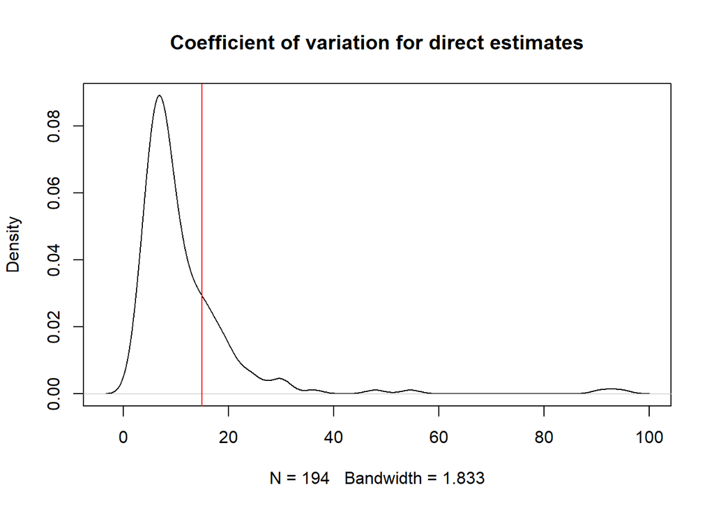

```r
# jpeg(paste(outputs, "direct_CV_histogram.jpg", sep="\\"),
#       width = 700, height = 500)
d <- density(prov.dir.svy$CV,prob=TRUE, main="",
     xlab="Coefficient of variation for direct estimates",
     breaks = c(0,5,10,15,20,40,100), labels=T)
plot(d, main="Coefficient of variation for direct estimates")
abline(v=15, col="red")
```

```r
# mtext("CV of 15", side = 0.5, line = 0.5, cex = 0.7, adj = 0)
```

Check normality of the direct estimates and plot CDF

```r
summary(prov.dir.svy$ANEMIA)
```

```
##    Min. 1st Qu.  Median    Mean 3rd Qu.    Max.
## 0.09989 0.29554 0.37680 0.39311 0.46377 0.73686
```

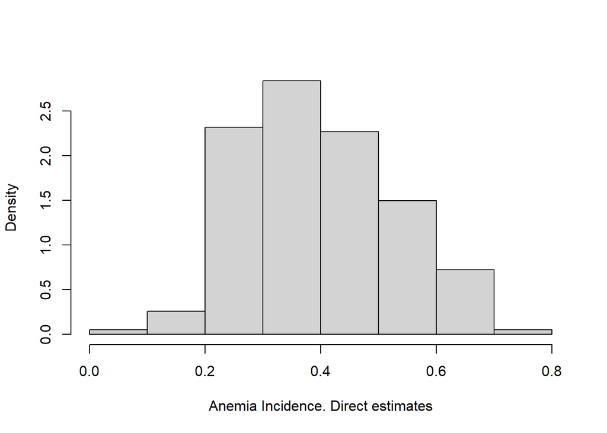

```r
# jpeg(paste(outputs, "direct_estim_histogram.jpg", sep="\\"),
#       width = 600, height = 400)
hist(prov.dir.svy$ANEMIA,prob=TRUE, main="",
    xlab="Anemia Incidence. Direct estimates")
```

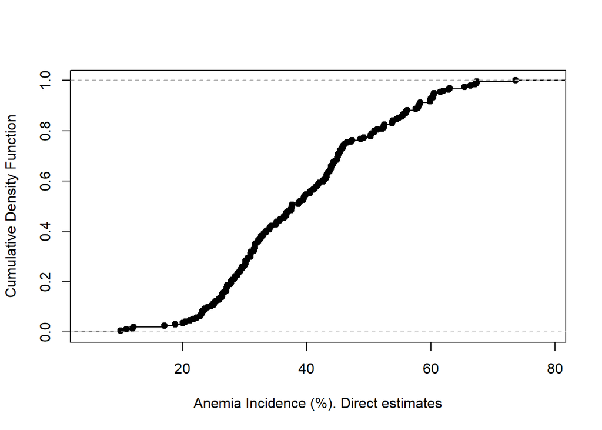

```r
# jpeg(paste(outputs, "direct_estim_CDF.jpg", sep="\\"),
#       width = 600, height = 400)
plot(ecdf(prov.dir.svy$ANEMIA*100),
     xlab="Anemia Incidence (%). Direct estimates",
     ylab='Cumulative Density Function',
     main='')
```

Formal tests of normality

```r
#testing normality
shapiro.test(prov.dir.svy$ANEMIA)
```

```
##
##  Shapiro-Wilk normality test
##
## data:  prov.dir.svy$ANEMIA
## W = 0.97989, p-value = 0.006896
```

```r
ks.test(prov.dir.svy$ANEMIA, 'pnorm')
```

```
##
##  One-sample Kolmogorov-Smirnov test
##
## data:  prov.dir.svy$ANEMIA
## D = 0.54891, p-value < 2.2e-16
## alternative hypothesis: two-sided
```

```r
jarque.test(prov.dir.svy$ANEMIA)
```

```
##
##  Jarque-Bera Normality Test
##
## data:  prov.dir.svy$ANEMIA
## JB = 4.7952, p-value = 0.09094
## alternative hypothesis: greater
```

```r
print(paste("Skweness", skewness(prov.dir.svy$ANEMIA)))
```

```
## [1] "Skweness 0.300804189927927"
```

```r
print(paste("Kurtosis", kurtosis(prov.dir.svy$ANEMIA)))
```

```
## [1] "Kurtosis 2.51907672483734"
```

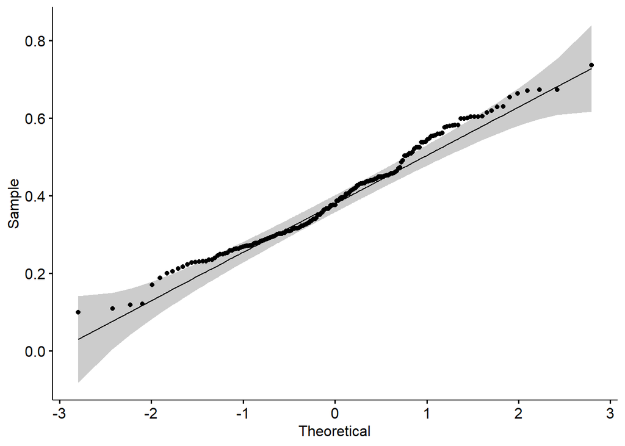

```r
ggqqplot(prov.dir.svy$ANEMIA)
```

## 2. Pre-processing

### 2.1 Predictors

We load the dataframe with all the potential predictors to use in the modelling stage. This variables are provincial averages and counts from Population Census, Agricultural Census and administrative registries. We have ~550 variables that comprise our candidate pool for the predictive stage in the Fay-Herriot.

```r
#load
covar_CPV <- read_dta(paste(data, "covariates",
                            "censo2017_stats_prov_hogar.dta",
                            sep="\\"))

#Filter provinces. Drop vars with NA
covar_CPV <- covar_CPV %>%
                      filter(!(covar_CPV$prov=="1608" |
                              covar_CPV$prov=="0209")) %>%
                      select_if(~ !any(is.na(.)))

# Drop vars with 0 variance
NZV_CPV <- nearZeroVar(covar_CPV)
print(paste("Fraction of nearZeroVar columns:",
            round(length(NZV_CPV)/length(covar_CPV),4)))
```

```
## [1] "Fraction of nearZeroVar columns: 0.0123"
```

```r
covar_CPV <- covar_CPV[, -NZV_CPV]

#labels
covar_CPV_labels <- var_label(covar_CPV)
```

```r
#load
covar_INEI <- read_dta(paste(data, "covariates",
                            "BASE_PROV.dta",
                            sep="\\"))

#Filter provinces. Drop vars with NA
covar_INEI <- covar_INEI %>%
                      filter(!(covar_INEI$PROV=="1608" |
                              covar_INEI$PROV=="0209")) %>%
                      select_if(~ !any(is.na(.)))

# Drop vars with 0 variance
NZV <- nearZeroVar(covar_INEI)
print(paste("Fraction of nearZeroVar columns:",
            round(length(NZV)/length(covar_INEI),4)))
```

```
## [1] "Fraction of nearZeroVar columns: 0.0998"
```

```r
covar_INEI <- covar_INEI[, -NZV]

#labels
covar_INEI_labels <- var_label(covar_INEI)
```

### 2.2 Create spatial matrix

Now, we load the provincial shapefile and create the contiguity matrix to compute the Spatial version of the Fay-Herriot model (SFH). We employ the more general standardized “queen” matrix.

```r
sf::sf_use_s2(FALSE)
```

```
## Spherical geometry (s2) switched off
```

```r
shp <- st_read(dsn = paste(data, "shapes", "PROVINCIA_19_12_2015.shp", sep="\\"))
#Filter provinces. Drop vars with NA
shp <- shp %>%
              filter(!(shp$IDPROV=="1608" |
                       shp$IDPROV=="0209"))
shp_sp <- readOGR(paste(data, "shapes", "PROVINCIA_19_12_2015.shp", sep="\\"))
#The centroids:
shp_centroid <- st_point_on_surface(x = shp)
#The euclidian distance matrix:
mtx_distance <- st_distance(shp_centroid, shp_centroid)

#Queen matrix: may need tmap spdep rgdal
wm_q <- poly2nb(shp, queen = TRUE)
```

```
## although coordinates are longitude/latitude, st_intersects assumes that they are planar
```

```r
wmat <- nb2mat(wm_q, style="W", zero.policy=TRUE)
```

We test the spatial correlation of anemia at the province level. We observe a positive and moderate spatial correlation of 0.5 by the Moran’s I.

```r
# Spatial correlation test (Moran goes [-1, 1])
spatialcor.tests(direct = prov.dir.svy$ANEMIA,
                 corMatrix = wmat)
```

```
##   Statistics     Value      p.value
## 1  Moran's I 0.4641480 3.375925e-25
## 2  Geary's C 0.5415304 1.327311e-21
```

Following Molina & Maruenda documentation of the SAE package, the Spatial Fay Herriot model will be

$$\tilde \delta^{FH}_{p} = x^{'}_{p}\tilde\beta + u_p + e_p$$

Where $\tilde \delta^{FH}_{p}$ is the vector of direct (Horvitz-Thompson) estimates for the P small areas, $x^{'}_{p}$ is a matrix containing in its columns the values of explanatory variables for the areas, $u_p$ is the vector of area effects and $e_p$ is the vector of independent sampling errors, independent of $u_p$ , with $e_p \sim N(0_p, \Psi_p)$ where the covariance matrix $\Psi_p$ is known.

The vector $u_p$ follows an simultaneously autoregressive (SAR) process with unknown autoregression parameter and proximity matrix $W$

$$u_p=\rho Wu_p + \eta_p$$
We assume that the matrix $(I_p-\rho W)$ is non-singular, where $I_p$ denotes the identity matrix. Then $u_p$ be expressed as

$$u_p=(I_p-\rho W)^{-1} \eta_p$$
where $\eta_p$ satisfies $\eta_p\sim N(0_p, AI_p)$ for $A$ unknown.

The matrix $W$ is obtained from an original proximity matrix $W^0$, whose diagonal elements area equal to zero and the remaining entries are equal to 1 when the two areas corresponding to the row and the column indices are considered as neighbor and zero otherwise. Then $W$ is obtained by row-standardization of $W^0$, obtained by dividing each entry $W^0$of by the sum of elements in the same row, see Anselin (1988). In our case, we are employing a queen proximity matrix.

### 2.3 Full dataframe with standardized covariates

Combine dataframe with direct estimates and all covariates. Standardize covariates

```r
#combine direct estimates and X's
combined_data <- data.frame(prov.dir.svy$ANEMIA, prov.dir.svy$ID_PROV)
not_candidates <- c( "ANEMIA", "ID_PROV")
colnames(combined_data) <- not_candidates

combined_data <- merge(combined_data,
                       transform(covar_CPV, prov = as.numeric(prov)),
                       by.x="ID_PROV", by.y="prov")
combined_data <- merge(combined_data,
                       transform(covar_INEI, PROV = as.numeric(PROV)),
                       by.x="ID_PROV", by.y="PROV")

#Standardize all covars except ID and direct estim
combined_data[,!names(combined_data) %in% not_candidates] <-
  scale(combined_data)[,!names(combined_data) %in% not_candidates]

rm(covar_CPV, covar_INEI)
```

## 3. Benchmark model: Expert’s selection Spatial Fay-Herriot

### 3.1 Expert covariates selection

We interviewed four experts in Peru. They all agreed in seven variables (intersection criteria)

```r
expert.vars <- c("SIEN_CLAP_PCDP2017_PROV", "SIS_CRED_M_17191_PROV",
                 "RNU_SIS_PROV", "SIS_CRED_M_17194_PROV", "SIS_CRED_M_17193_PROV",
                 "POBREZA_PT_PROV", "SIS_CRED_M_17192_PROV")

#Selected vars dataframe
experts.vars.df <- data.matrix(cbind(const=rep(1,D-1),
                                   combined_data[,names(combined_data)
                                                 %in% c(expert.vars)]))
```

### 3.2 Run SFH with variables selected by experts

```r
expert.model <- SpatialFH(prov.dir.svy$ANEMIA, # direct estimate
                           experts.vars.df, # predictor vars
                           (prov.dir.svy$se)^2, # direct estim variance
                           wmat) # contiguity matrix
```

## 4. Stepwise Spatial Fay-Herriot

For this model, we perform a bidirectional stepwise selection using 2° order AIC as criteria. We include a significance level of 0.05 or below to be more restrictive with the number of variables selected.

### 4.1 Stepwise selection

```r
#Formula
y <- "ANEMIA"
x_candidates <- colnames(combined_data[,!names(combined_data)
                                        %in% not_candidates])
step_formula <- as.formula(paste(y, " ~ ", paste(x_candidates,
                                          collapse= "+")))
```

```r
#Stepwise
stp.sel <- stepwise(formula=step_formula,
                    data=combined_data,
                    selection="bidirection", #bidirection, score
                    sle=0.05, # significance is irrelevant
                    sls=0.05, # significance is irrelevant
                    select="AICc") #2°order AIC, ↑penalization if ↓n

#Selected vars (no constant)
stepw.vars <- stp.sel[["Varaibles"]][!stp.sel[["Varaibles"]] %in% c('1')]

#Selected vars dataframe
stepw.vars.df <- data.matrix(cbind(const=rep(1,D-1),
                                   combined_data[,names(combined_data)
                                                 %in% c(stepw.vars)]))
print(paste("Number of variables selected:", length(stepw.vars)))
```

```
## [1] "Number of variables selected: 14"
```

```r
stepw.vars
```

```
##  [1] "c3p16_1"                    "ECE_MATE_PREVIO_PARTI_PROV"
##  [3] "CE_LOCALPAR2_PROV"          "c3p24_3"
##  [5] "c3p23_2"                    "ECE_MATE_PROCES_ESTAT_PROV"
##  [7] "c3p210_2"                   "SIEN_A635_PCAT2018_PROV"
##  [9] "SIEN_A635_PCAS2018_PROV"    "SIEN_A659_PCAS2018_PROV"
## [11] "c3p21_3"                    "c3p215_2"
## [13] "SIEN_A659_PCAL2018_PROV"    "c3p28_3"
```

### 4.2 Run SFH with selected variables by stepwise

```r
stepw.model <- SpatialFH(prov.dir.svy$ANEMIA, # direct estimate
                         stepw.vars.df, # predictor vars
                         (prov.dir.svy$se)^2, # direct estim variance
                         wmat) # contiguity matrix
```

## 5. LASSO Spatial Fay-Herriot

In contrast with stepwise selection, LASSO is very sensitive to high correlation in predictor variables (see, Hastie, et al 2009). This may result in LASSO choosing randomly between a pair of predictor that are correlated. Additionally, as we are inverting a matrix to compute the solution, correlations near one may cause problems by creating an (almost) singular matrix.

```r
noncorr_data_all <- data.frame(cbind(combined_data, prov.dir.svy$CV))
noncorr_data_all <- noncorr_data_all[noncorr_data_all$prov.dir.svy.CV < 15,]
```

```r
noncorr_data <- noncorr_data_all[,!names(noncorr_data_all)
                                        %in% c(not_candidates, "prov.dir.svy.CV")]
df2 = cor(noncorr_data)
hc = findCorrelation(df2, cutoff=0.7) #cutoff is taken as abs()
hc = sort(hc)
noncorr_data  = noncorr_data[,-c(hc)]

## paste ID and y = ANEMIA
noncorr_data <- data.frame(cbind(noncorr_data_all[,names(noncorr_data_all)
                                                  %in% not_candidates],
                                 noncorr_data))
rm(noncorr_data_all, df2, hc)
```

### 5.1 LASSO selection with GridSearch for optimal lambda

Here, I will use GridSearch for optimal lambda going from 0 (OLS) to the value that makes all slopes=0. I will not be using cross-validation for several reasons:

- We will not predict out of sample
- If we do train-test splitting, we cannot include province random effects (RE). This because each province has only one observation, hence the test sample will have RE for provinces not seen in the training data. The algorithm will not be able to predict as it does not have this slopes.
- We can include region RE (subnational level 1) but this will not be ideal as the SFH uses province RE.

```r
#Formula
y <- "ANEMIA"
x_candidates <- colnames(noncorr_data[,!names(noncorr_data)
                                        %in% not_candidates])
lasso_formula <- as.formula(paste(y, " ~ ", paste(x_candidates,
                                          collapse= "+")))
```

```r
noncorr_data$ID_PROV <- factor(noncorr_data$ID_PROV)

#family
family = gaussian(link="identity")

#lambda grid
lambda <- seq(15, 0, by=-0.5) # lambda=15 makes all coef=0

#AIC y BIC vector to choose best model (only from training)
BIC_vec <- rep(Inf, length(lambda))
AIC_vec <- rep(Inf, length(lambda))
sse <- rep(Inf, length(lambda)) # sum of squared errors
```

```r
# Iterate for each lambda in each fold
for(j in 1:length(lambda)) {

  print(paste("Iteration ", j, sep=""))

 #model fit
  glm2 <- try(glmmLasso(lasso_formula,
                        rnd = list(ID_PROV = ~1), #random effects
                        lambda=lambda[j],
                        family = family, data = noncorr_data,
                        switch.NR=F, final.re=TRUE,
                        control=list(print.iter=F))
              ,silent=TRUE)

  if(class(glm2) != "try-error"){
    BIC_vec[j]<-glm2$bic
    AIC_vec[j]<-glm2$aic
    sse[j]<-sum((glm2$y_hat-noncorr_data$ANEMIA)**2)
  }
}
```

Optimal model

```r
# Lambda that minimizes SSE
opt2 <- which.min(sse)

# Fit model with optimal lambda
glm2_final <- glmmLasso(lasso_formula,
                        rnd = list(ID_PROV = ~1), #random effects
                        lambda=lambda[opt2],
                        family = family, data = noncorr_data,
                        switch.NR=F,final.re=TRUE,
                        control = list(print.iter=F))
```

```r
# Obtain selected variables
df2 <- data.frame(glm2_final$coefficients)
df2 <- cbind(vars = rownames(df2), df2)
df2 <- filter(df2, glm2_final.coefficients!=0) %>% #non selected
       filter(row_number()!=1) #intercept
lasso.vars <- df2$vars

#Selected vars df
lasso.vars.df <- data.matrix(cbind(const=rep(1,D-1),
                                   combined_data[,names(combined_data)
                                                 %in% c(lasso.vars)]))
print(paste("Number of variables selected:", length(lasso.vars)))
```

```
## [1] "Number of variables selected: 97"
```

```r
lasso.vars
```

```
##  [1] "c3p13_1"                    "c3p14_2"
##  [3] "c3p16_2"                    "c3p17_2"
##  [5] "c3p18_1"                    "c3p215_2"
##  [7] "c3p216_2"                   "c3p3_1"
##  [9] "c3p3a"                      "thombres"
## [11] "ECE_LENG_PROCES_ESTAT_PROV" "ECE_LENG_PREVIO_PARTI_PROV"
## [13] "ECE_MATE_INI_PROV"          "SIEN_ANEMIA_PCAS2017_PROV"
## [15] "SIEN_ANEMIA_PCAS2018_PROV"  "SIEN_ANEMIA_PCAL2019_PROV"
## [17] "SIEN_ANEMIA_PCAS2019_PROV"  "SIEN_IMC_PCBP2017_PROV"
## [19] "SIEN_IMC_PCSP2019_PROV"     "SIEN_CLAP_PCDP2019_PROV"
## [21] "SIEN_A635_PCAT2017_PROV"    "SIEN_A659_PCAS2018_PROV"
## [23] "SIS_VAC_M_17192_PROV"       "SIS_VAC_M_17196_PROV"
## [25] "SIS_TALLA_M_17191_PROV"     "SIS_TALLA_M_17192_PROV"
## [27] "SIS_CRED_M_17192_PROV"      "SIS_CRED_M_17193_PROV"
## [29] "SIS_CRED_M_17194_PROV"      "CE_LOCALPAR2_PROV"
```

[output cut: 34 more lines]

```r
#rm(df2)
```

Plotting lambdas

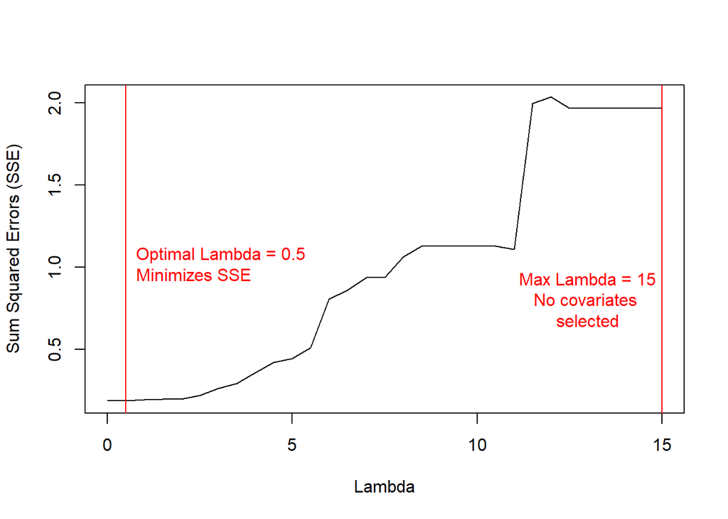

```r
lambda.df <- data.frame(lambda, sse)

# jpeg(paste(outputs, "lambda_plot.jpg", sep="\\"),
#      width = 500, height = 500)

plot(lambda.df$lambda, lambda.df$sse,  type="l", xlab="Lambda", ylab="Sum Squared Errors (SSE)", ) #ylim=c(0,10))
abline(v=lambda[opt2], col="red")
abline(v=max(lambda), col="red")
lbl <- paste0("Optimal Lambda = ",
              as.character(lambda[opt2]), "\nMinimizes SSE")
lbl2 <- paste0("Max Lambda = ",
               as.character(max(lambda)), "\nNo covariates \nselected")
text(lambda[opt2], max(1), label = lbl, col="red", pos = 4)
text(max(lambda)-2, max(1), label = lbl2, col="red", pos = 1)
```

### 5.2 Run SFH with selected variables

```r
lasso.model <- SpatialFH(prov.dir.svy$ANEMIA, # direct estimate
                         lasso.vars.df, # predictor vars
                         (prov.dir.svy$se)^2, # direct estim variance
                         wmat) # contiguity matrix
```

## 6. Sparse PCA Spatial Fay-Herriot

As we see from above, LASSO selects a high number of variables. This behaviour has been highlighted by Hastie et al (2009) and Hastie et al (2015) as troublesome since a LASSO regression with many covariates will likely selected a number of predictors (K) equal to the number of observations (N). This is what we believe is happening in our case, as we have 152 obs in the training, and ~100 predictors, which is not a very parsimonious model.

In order to try a different approach, we implement a method coming from the multidimensionaly reduction literature, which is also part of the Machine Learning methods. This is the Sparse PCA, which is an extension of the PCA that performs variable selection. As noted by the authors of the package, the Sparse PCA avoids overfitting in a high-dimensional data setting where the number of variables K is greater than the number of observations n. The method attempts to find sparse weight vectors (loadings), i.e., a weight vector with only a few ‘active’ (nonzero) values.

### 6.1 Sparse PCA selection

We use the [one-in-twenty](https://en.wikipedia.org/wiki/One_in_ten_rule) as the max number of components to be chosen.

```r
X <- (combined_data[,!names(combined_data)
                            %in% not_candidates])

#Default values. We increase regularization by 100 for a sparse solution as the default value and the value multiplied by 6 gave us >90 predictors.
out <- rspca(X, k = round(nrow(X)/20), #one-in-twenty rule
             alpha = 1e-04, beta = 1e-04,
             center = TRUE, scale = FALSE,
             max_iter = 1000, tol = 1e-05,
             o = 10, q = 2,
             verbose = F)

#PC scores are computed as  Z = XB, where B are the loadings
#Keep the PC with variance
Z <- out$scores
#delete any potential vector with no variance
if (length(nearZeroVar(Z)) != 0) {
  Z <- Z[, -nearZeroVar(Z)]
}

#Selected vars dataframe, add constant
sPCA.vars.df <- data.matrix(cbind(const=rep(1,D-1), Z))

print(paste0("Number of components: ", ncol(Z)))
```

```
## [1] "Number of components: 10"
```

Total variance explained

```r
print(paste0("Prop. of variance explained by last component: ", summary(out)[3,ncol(Z)]))
```

```
## [1] "Prop. of variance explained by last component: 0.01"
```

```r
print(paste0("Total Variance explained: ", summary(out)[4,ncol(Z)]))
```

```
## [1] "Total Variance explained: 0.792"
```

### 6.2 Run SFH with selected variables

```r
sPCA.model <- SpatialFH(prov.dir.svy$ANEMIA, # direct estimate
                         sPCA.vars.df, # predictor vars
                         (prov.dir.svy$se)^2, # direct estim variance
                         wmat) # contiguity matrix
```

## 7 Plotting

In this section, we will plot estimates, standard errors and CV to check the improvement of the models versus the direct estimates. This will also let us contrast rival models.

```r
# vars for x-axis
ln_nd <- log(nd)
ln_nd_ <- log(nd_)
o<-order(nd_)
```

### 7.1 Create an estimates dataframe

We merge all estimates and their corresponding MSE, CV, etc. in one dataframe. We also compute ratios of the model estimates and their dispersion in relation to the direct estimates.

```r
compar.df <- data.frame(ID_PROV = prov.dir.svy$ID_PROV,
                        sample.size = nd_,

                        dir.estim = prov.dir.svy$ANEMIA,
                        dir.se = prov.dir.svy$se,
                        dir.var = (prov.dir.svy$se)^2,
                        dir.cv = prov.dir.svy$CV,

                        expert.estim = expert.model$SFH.estimates,
                        expert.mse = expert.model$SFH.mse,
                        expert.cv = expert.model$SFH.cv,

                        stepw.estim = stepw.model$SFH.estimates,
                        stepw.mse = stepw.model$SFH.mse,
                        stepw.cv = stepw.model$SFH.cv,

                        lasso.estim = lasso.model$SFH.estimates,
                        lasso.mse = lasso.model$SFH.mse,
                        lasso.cv = lasso.model$SFH.cv,

                        sPCA.estim = sPCA.model$SFH.estimates,
                        sPCA.mse = sPCA.model$SFH.mse,
                        sPCA.cv = sPCA.model$SFH.cv)

#generate ratios
##experts
compar.df$expert.est.ratio <- (compar.df$dir.estim/compar.df$expert.estim)*100
compar.df$expert.se.ratio <- ((compar.df$dir.se)/sqrt(compar.df$expert.mse))*100
compar.df$expert.cv.ratio  <- (compar.df$dir.cv/compar.df$expert.cv)*100

##stepwise
compar.df$stepw.est.ratio <- (compar.df$dir.estim/compar.df$stepw.estim)*100
compar.df$stepw.se.ratio <- ((compar.df$dir.se)/sqrt(compar.df$stepw.mse))*100
compar.df$stepw.cv.ratio  <- (compar.df$dir.cv/compar.df$stepw.cv)*100

##lasso
compar.df$lasso.est.ratio <- (compar.df$dir.estim/compar.df$lasso.estim)*100
compar.df$lasso.se.ratio <- ((compar.df$dir.se)/sqrt(compar.df$lasso.mse))*100
compar.df$lasso.cv.ratio  <- (compar.df$dir.cv/compar.df$lasso.cv)*100

##sPCA
compar.df$sPCA.est.ratio <- (compar.df$dir.estim/compar.df$sPCA.estim)*100
compar.df$sPCA.se.ratio <- ((compar.df$dir.se)/sqrt(compar.df$sPCA.mse))*100
compar.df$sPCA.cv.ratio  <- (compar.df$dir.cv/compar.df$sPCA.cv)*100
```

### 7.2 Estimates convergence plot

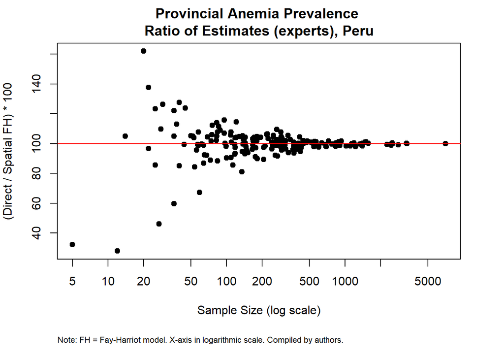

```r
xlabel <- "Sample Size (log scale)"
ylabel <- "(Direct / Spatial FH) * 100"
note <- "Note: FH = Fay-Harriot model. X-axis in logarithmic scale. Compiled by authors."

# jpeg(paste(outputs, "estimratio_Dir-vs-experts.jpg", sep="\\"),
#      width = 500, height = 500)
title <- "Provincial Anemia Prevalence \nRatio of Estimates (experts), Peru"
converplot(nd_, compar.df$expert.est.ratio, title, xlabel, ylabel, note)
```

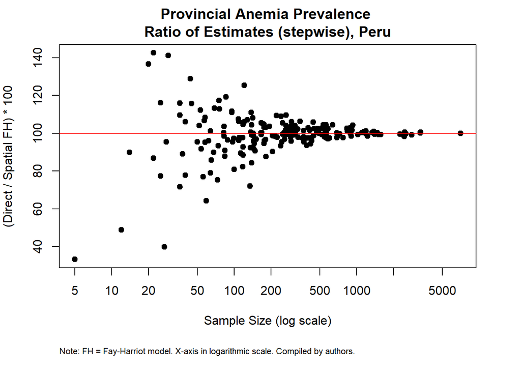

```r
# jpeg(paste(outputs, "estimratio_Dir-vs-stepw.jpg", sep="\\"),
#      width = 500, height = 500)
title <- "Provincial Anemia Prevalence \nRatio of Estimates (stepwise), Peru"
converplot(nd_, compar.df$stepw.est.ratio, title, xlabel, ylabel, note)
```

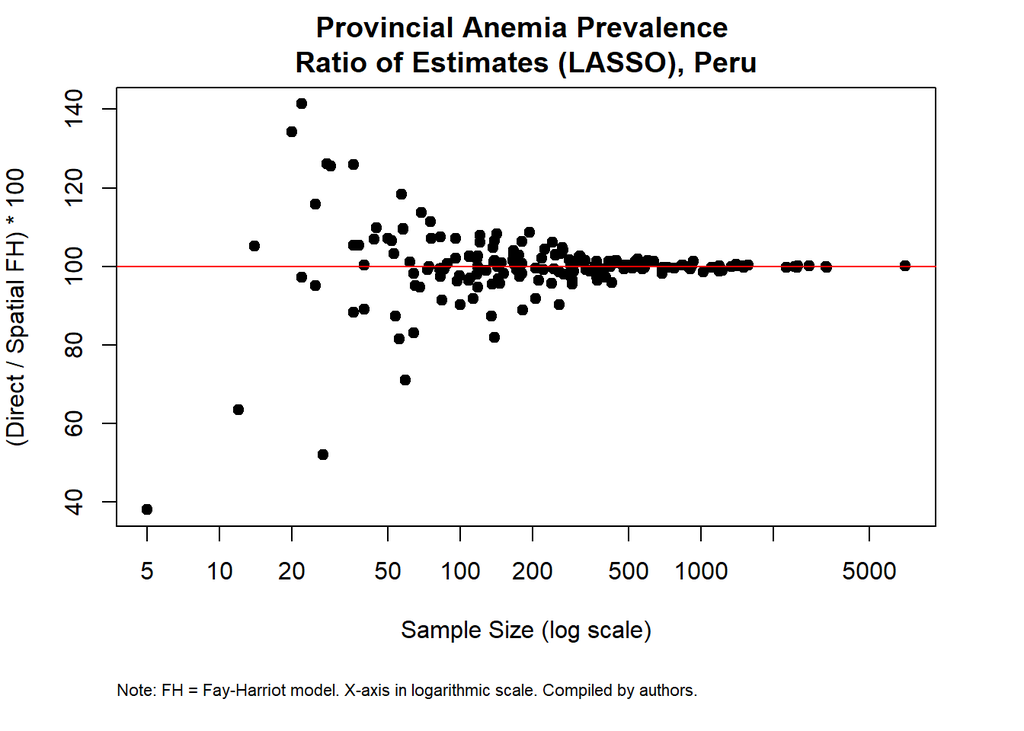

```r
# jpeg(paste(outputs, "estimratio_Dir-vs-lasso.jpg", sep="\\"),
#      width = 500, height = 500)
title <- "Provincial Anemia Prevalence \nRatio of Estimates (LASSO), Peru"
converplot(nd_, compar.df$lasso.est.ratio, title, xlabel, ylabel, note)
```

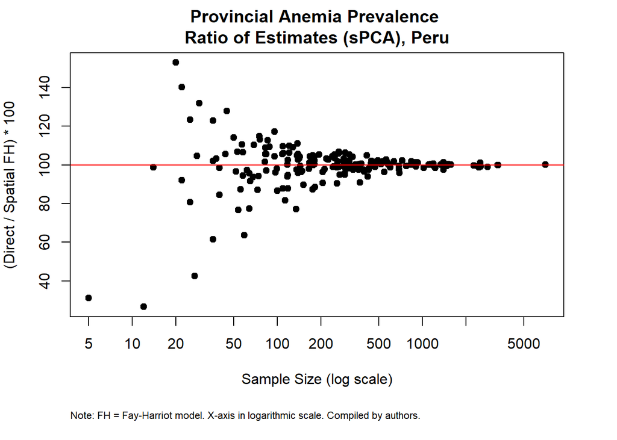

```r
# jpeg(paste(outputs, "estimratio_Dir-vs-sPCA.jpg", sep="\\"),
#      width = 500, height = 500)
title <- "Provincial Anemia Prevalence \nRatio of Estimates (sPCA), Peru"
converplot(nd_, compar.df$sPCA.est.ratio, title, xlabel, ylabel, note)
```

### 7.3 Standard error ratios convergence plot

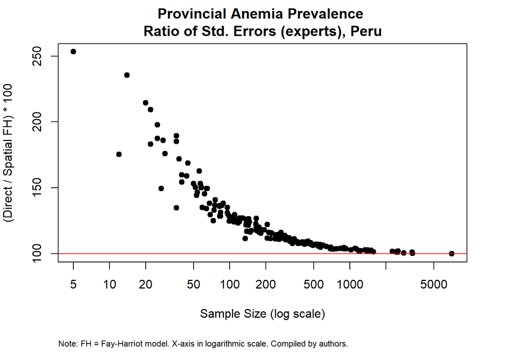

```r
xlabel <- "Sample Size (log scale)"
ylabel <- "(Direct / Spatial FH) * 100"
note <- "Note: FH = Fay-Harriot model. X-axis in logarithmic scale. Compiled by authors."

# jpeg(paste(outputs, "stdratio_Dir-vs-experts.jpg", sep="\\"),
#      width = 500, height = 500)
title <- "Provincial Anemia Prevalence \nRatio of Std. Errors (experts), Peru"
converplot(nd_, compar.df$expert.se.ratio, title, xlabel, ylabel, note)
```

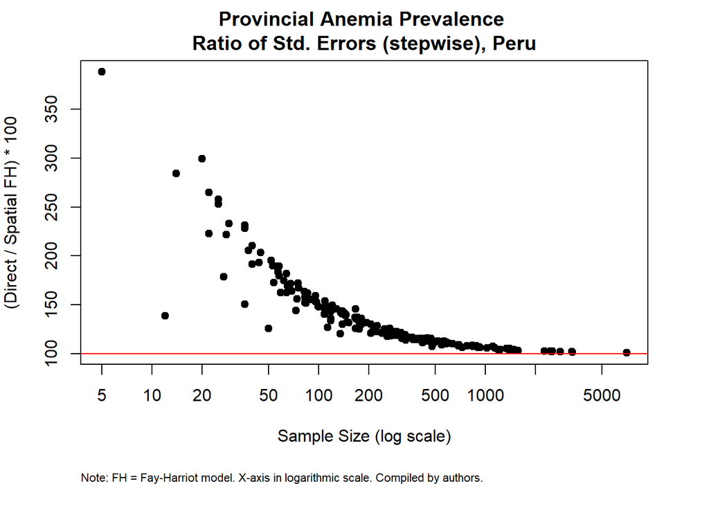

```r
# jpeg(paste(outputs, "stdratio_Dir-vs-stepw.jpg", sep="\\"),
#      width = 500, height = 500)
title <- "Provincial Anemia Prevalence \nRatio of Std. Errors (stepwise), Peru"
converplot(nd_, compar.df$stepw.se.ratio, title, xlabel, ylabel, note)
```

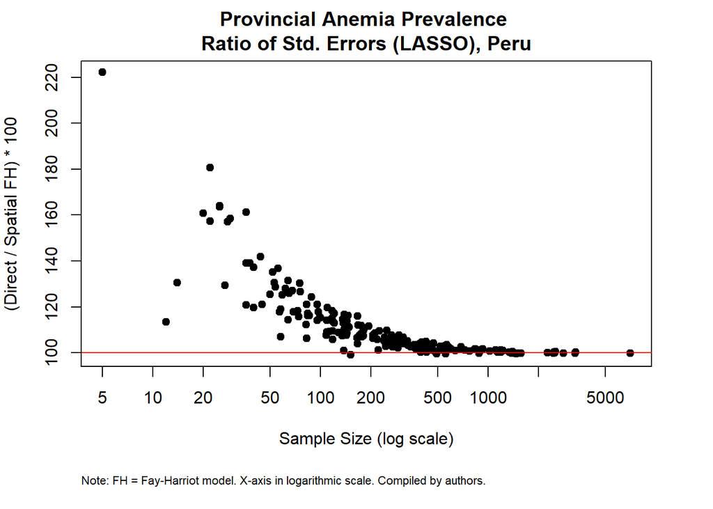

```r
# jpeg(paste(outputs, "stdratio_Dir-vs-lasso.jpg", sep="\\"),
#      width = 500, height = 500)
title <- "Provincial Anemia Prevalence \nRatio of Std. Errors (LASSO), Peru"
converplot(nd_, compar.df$lasso.se.ratio, title, xlabel, ylabel, note)
```

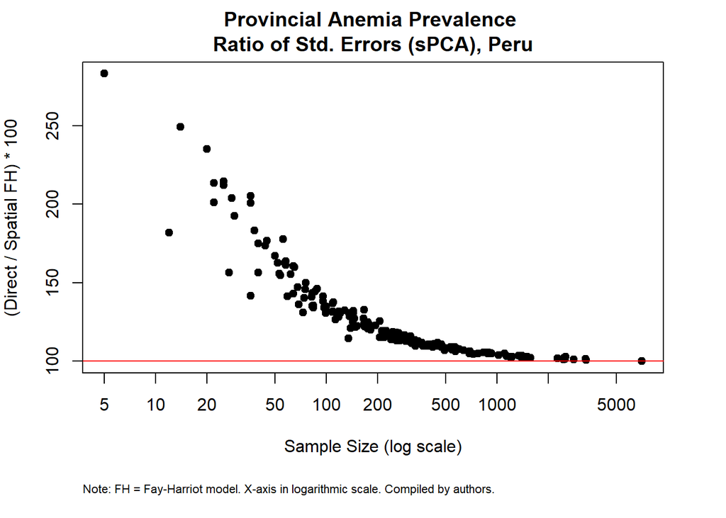

```r
# jpeg(paste(outputs, "stdratio_Dir-vs-sPCA.jpg", sep="\\"),
#      width = 500, height = 500)
title <- "Provincial Anemia Prevalence \nRatio of Std. Errors (sPCA), Peru"
converplot(nd_, compar.df$sPCA.se.ratio, title, xlabel, ylabel, note)
```

### 7.4 CV and sample size

```r
#Top 10 provinces with smallest sample size
cv.df <- compar.df[c("sample.size", "dir.cv",
                     "expert.cv", "stepw.cv",
                     "lasso.cv", "sPCA.cv")][o[1:10],]
cv.df
```

```
##     sample.size   dir.cv expert.cv  stepw.cv lasso.cv   sPCA.cv
## 169           5 90.96939  11.59447  7.763257 15.54170  9.996263
## 11           12 94.52301  15.06101 33.263904 52.81345 13.813899
## 20           14 36.17265  16.12743 11.432350 29.14841 14.325400
## 129          20 20.84975  15.75976  9.517475 17.41802 13.552907
## 10           22 15.17865  11.40870  9.712027 11.88688 10.568905
## 39           22 29.79771  13.75125  9.764459 18.42281 12.871310
## 41           25 30.48283  13.93571  9.135327 17.71475 11.593048
## 52           25 18.38053  11.45004  8.439794 12.98712 10.581498
## 12           27 54.61400  16.83302 12.157396 21.92135 14.857464
## 122          28 30.63745  18.07059 13.198961 24.59468 15.698906
```

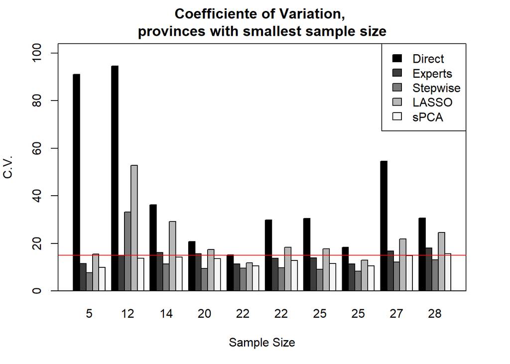

```r
# jpeg(paste(outputs, "CV-smallest-prov-allmodels.jpg", sep="\\"),
#      width = 750, height = 500)
mx <- t(as.matrix(cv.df[-1]))# t(as.matrix(DF[-3]))
colours = c("grey0","grey24", "grey48", "grey72", "grey96")
par(mar = c(5, 4, 3, 3))
barplot(mx,
        main='Coefficiente of Variation, \nprovinces with smallest sample size',
        ylab='C.V.', xlab='Sample Size',beside = TRUE,
        ylim=c(0,max(mx)*1.1), names.arg = cv.df$sample.size,
        col=colours)
# to add a box around the plot
box()

# add a legend
legend('topright',fill=colours,
       legend=c('Direct','Experts', 'Stepwise', 'LASSO', 'sPCA'))

abline(h=15, col="red")
```

### 7.6 Improvement of variance

```r
#generate ratio of improvement
##experts
compar.df$expert.improv.ratio <- ((compar.df$dir.var - compar.df$expert.mse)/compar.df$dir.var)*100

##stepw
compar.df$stepw.improv.ratio <- ((compar.df$dir.var - compar.df$stepw.mse)/compar.df$dir.var)*100

##lasso
compar.df$lasso.improv.ratio <- ((compar.df$dir.var - compar.df$lasso.mse)/compar.df$dir.var)*100

##sPCA
compar.df$sPCA.improv.ratio <- ((compar.df$dir.var - compar.df$sPCA.mse)/compar.df$dir.var)*100
```

```r
cols <- c("expert.improv.ratio", "stepw.improv.ratio", "lasso.improv.ratio", "sPCA.improv.ratio")
summary(compar.df[cols])
```

```
##  expert.improv.ratio stepw.improv.ratio lasso.improv.ratio sPCA.improv.ratio
##  Min.   :-0.0278     Min.   : 1.457     Min.   :-1.931     Min.   :-0.1155
##  1st Qu.:13.0981     1st Qu.:21.195     1st Qu.: 3.664     1st Qu.:15.6056
##  Median :24.2202     Median :34.773     Median :11.832     Median :27.9685
##  Mean   :28.4793     Mean   :38.767     Mean   :16.633     Mean   :32.0921
##  3rd Qu.:39.4440     3rd Qu.:54.441     3rd Qu.:24.968     3rd Qu.:44.4839
##  Max.   :84.4161     Max.   :93.372     Max.   :79.749     Max.   :87.5421
```

The Peruvian NSO uses a threshold of CV>15 to decide if estimates are published or not. We can count how many provincial estimates we are recovering in comparison with the direct estimation

```r
sum(compar.df$dir.cv>15)
```

```
## [1] 42
```

```r
sum(compar.df$expert.cv>15)
```

```
## [1] 13
```

```r
sum(compar.df$stepw.cv>15)
```

```
## [1] 3
```

```r
sum(compar.df$lasso.cv>15)
```

```
## [1] 25
```

```r
sum(compar.df$sPCA.cv>15)
```

```
## [1] 5
```

### 7.7 AIC, BIC, loglike. Summary of point estimate

```r
expert.goodness <- expert.model[["SFH.object"]][["fit"]][["goodness"]]
stepw.goodness <- stepw.model[["SFH.object"]][["fit"]][["goodness"]]
lasso.goodness <- lasso.model[["SFH.object"]][["fit"]][["goodness"]]
sPCA.goodness <- sPCA.model[["SFH.object"]][["fit"]][["goodness"]]

goodness_matrix <- rbind(expert.goodness, stepw.goodness, lasso.goodness, sPCA.goodness)

write.csv(goodness_matrix,
          file=paste(outputs, "goodness_matrix.csv", sep="\\"))
```

```r
estim.summary <- as.data.frame(apply(compar.df[c("dir.estim", "expert.estim", "stepw.estim", "lasso.estim", "sPCA.estim")], 2, summary))

write.csv(estim.summary,
          file=paste(outputs, "summary_estimates.csv", sep="\\"))

jpeg(paste(outputs, "boxplot_estim.jpg", sep="\\"),
     width = 800, height = 400)
boxplot(compar.df[c("dir.estim", "expert.estim", "stepw.estim", "lasso.estim", "sPCA.estim")],
        ylab = "Anemia Prevalence (%)", staplewex=T, outwex=T,
        border = c("grey"), col="white",
        names = c("Direct", "Experts", "Stepwise", "LASSO", "sPCA"))
```

### 7.8 Choropleths

We plot the provincial estimates of anemia in choropleths maps.

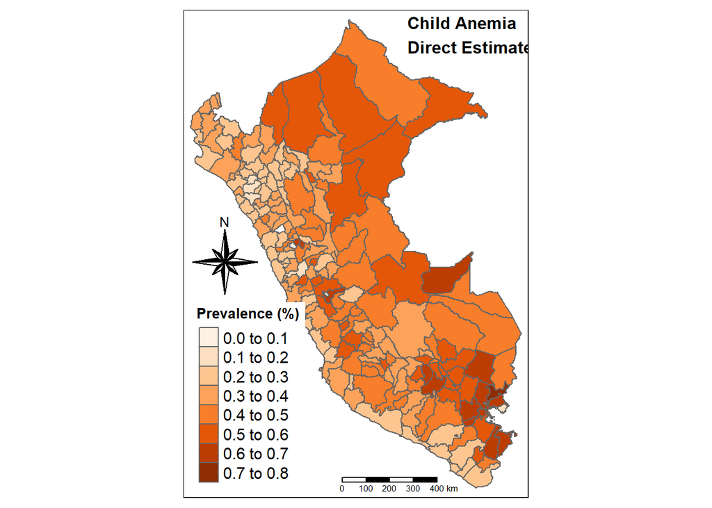

```r
# jpeg(paste(outputs, "map_direct.jpg", sep="\\"),
#      width = 400, height = 500)
title = "Child Anemia \nDirect Estimate"
choropleths(shp, compar.df, "ID_PROV", "dir.estim", title)
```

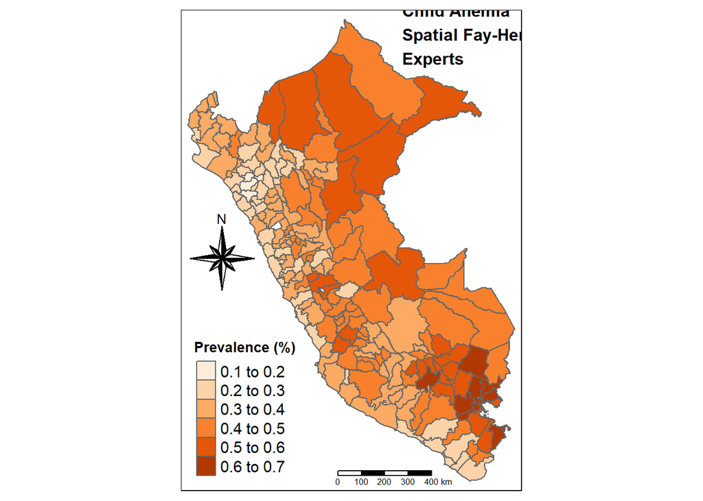

```r
# jpeg(paste(outputs, "map_expert.jpg", sep="\\"),
#      width = 400, height = 500)
title = "Child Anemia \nSpatial Fay-Herriot \nExperts"
choropleths(shp, compar.df, "ID_PROV", "expert.estim", title)
```

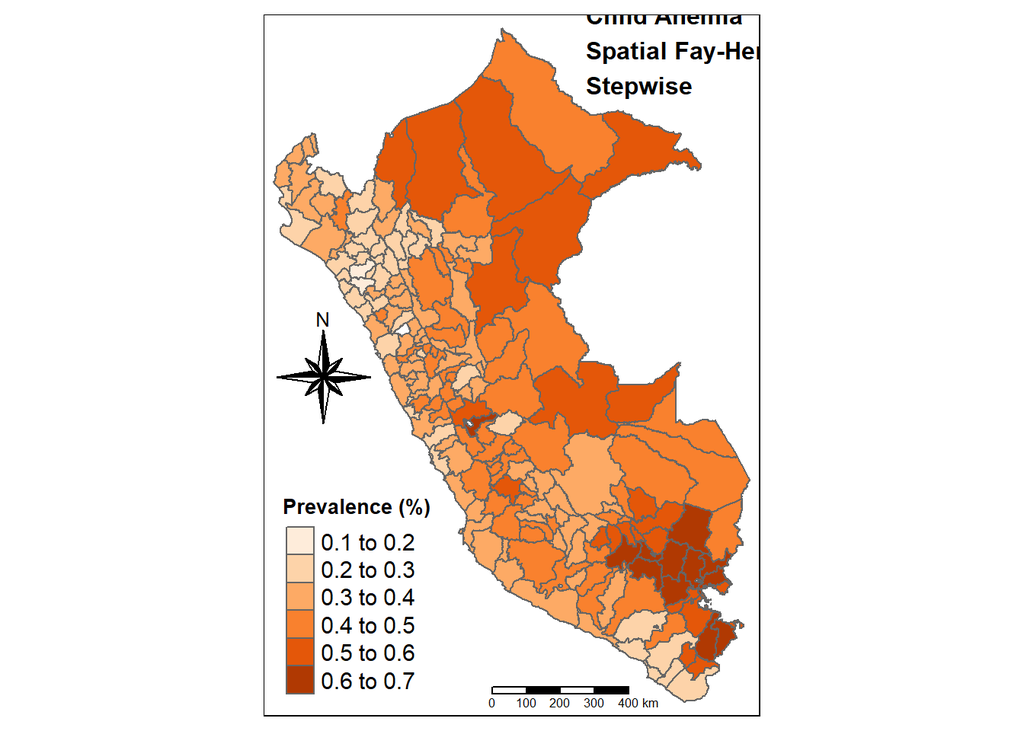

```r
# jpeg(paste(outputs, "map_stepw.jpg", sep="\\"),
#      width = 400, height = 500)
title = "Child Anemia \nSpatial Fay-Herriot \nStepwise"
choropleths(shp, compar.df, "ID_PROV", "stepw.estim", title)
```

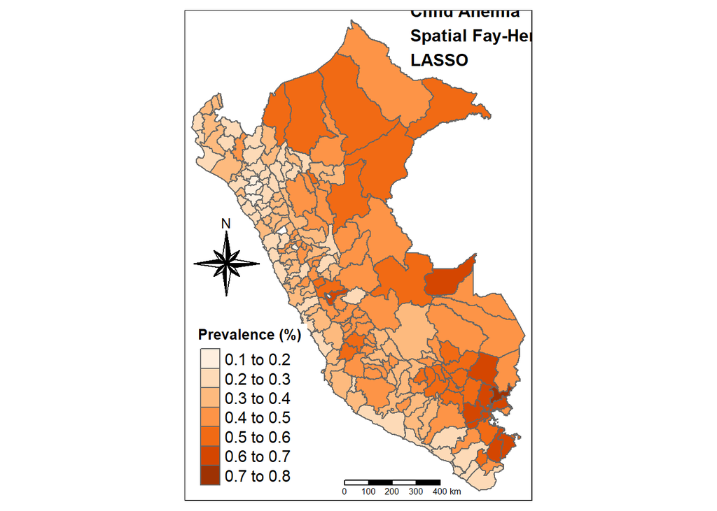

```r
# jpeg(paste(outputs, "map_lasso.jpg", sep="\\"),
#      width = 400, height = 500)
title = "Child Anemia \nSpatial Fay-Herriot \nLASSO"
choropleths(shp, compar.df, "ID_PROV", "lasso.estim", title)
```

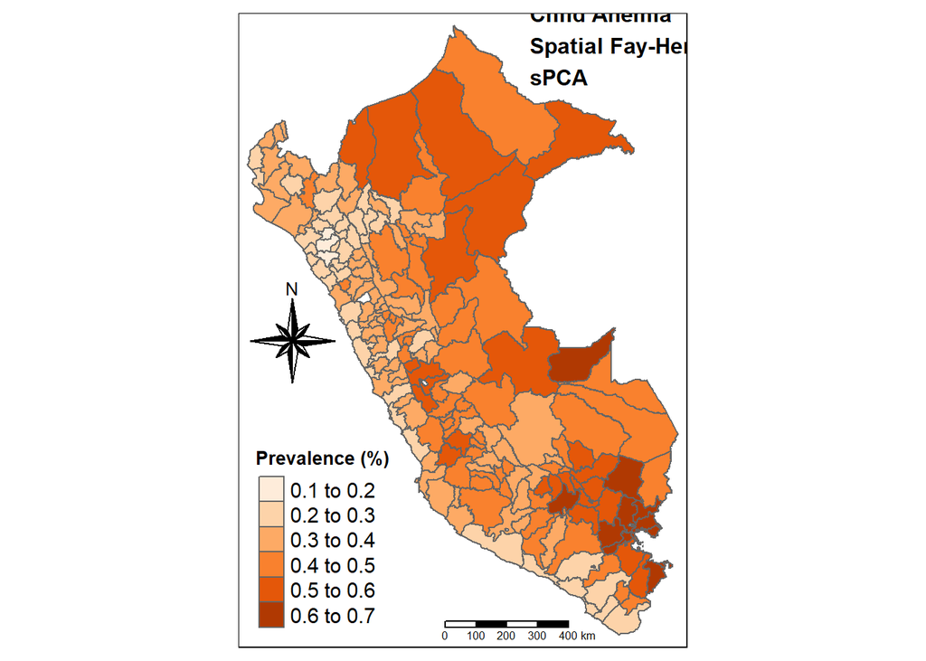

```r
# jpeg(paste(outputs, "map_sPCA.jpg", sep="\\"),
#      width = 400, height = 500)
title = "Child Anemia \nSpatial Fay-Herriot \nsPCA"
choropleths(shp, compar.df, "ID_PROV", "sPCA.estim", title)
```

We plot the same choropleths but we drop the estimates with a CV>15 which is the threshold used by the INEI to publish results.

```r
mapdf_1 <- compar.df
mapdf_1$dir.estim[mapdf_1$dir.cv > 15] <- NA
mapdf_1$expert.estim[mapdf_1$expert.cv > 15] <- NA
mapdf_1$stepw.estim[mapdf_1$stepw.cv > 15] <- NA
mapdf_1$lasso.estim[mapdf_1$lasso.cv > 15] <- NA
mapdf_1$sPCA.estim[mapdf_1$sPCA.cv > 15] <- NA
```

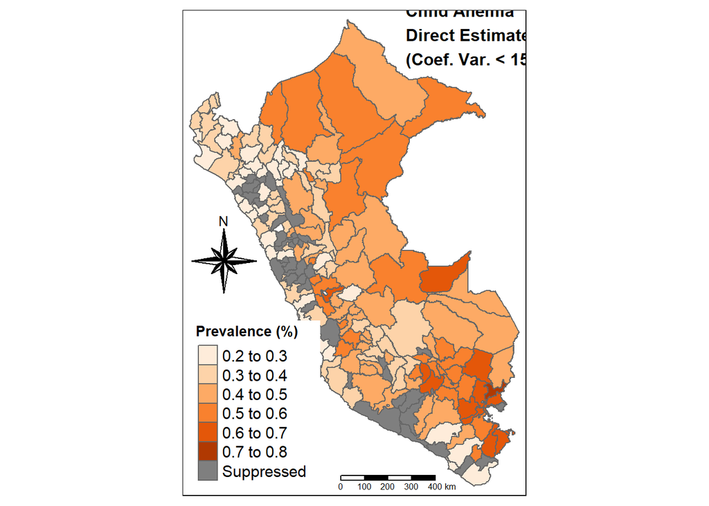

```r
# jpeg(paste(outputs, "map_direct_CV15.jpg", sep="\\"),
#      width = 400, height = 500)
title = "Child Anemia \nDirect Estimate \n(Coef. Var. < 15)"
choropleths(shp, mapdf_1, "ID_PROV", "dir.estim", title)
```

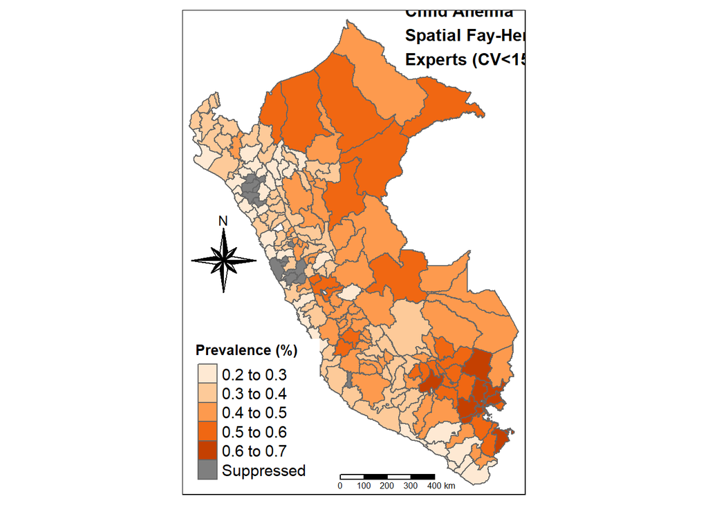

```r
# jpeg(paste(outputs, "map_expert_CV15.jpg", sep="\\"),
#      width = 400, height = 500)
title = "Child Anemia \nSpatial Fay-Herriot \nExperts (CV<15)"
choropleths(shp, mapdf_1, "ID_PROV", "expert.estim", title)
```

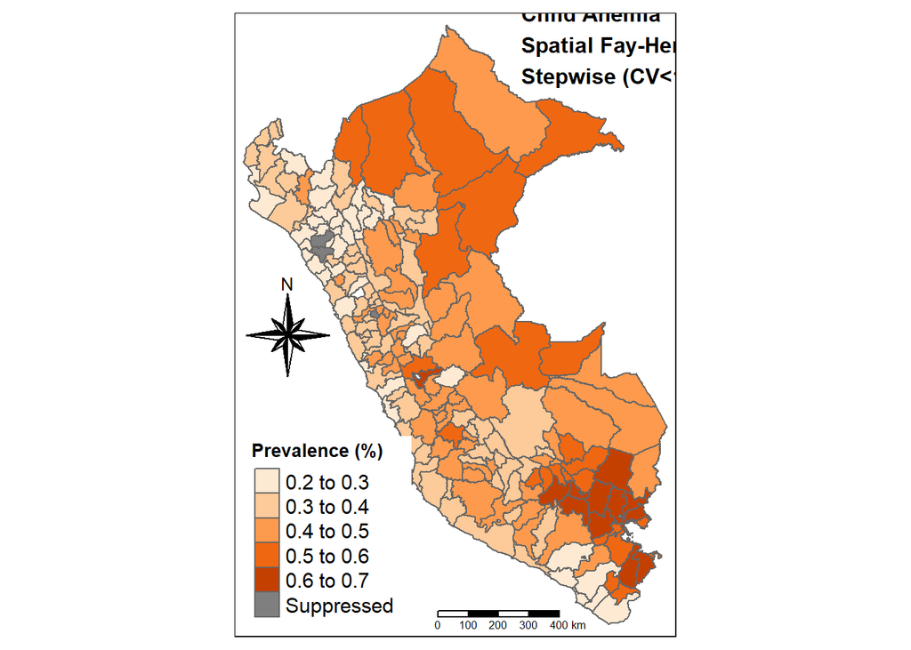

```r
# jpeg(paste(outputs, "map_stepw_CV15.jpg", sep="\\"),
#      width = 400, height = 500)
title = "Child Anemia \nSpatial Fay-Herriot \nStepwise (CV<15)"
choropleths(shp, mapdf_1, "ID_PROV", "stepw.estim", title)
```

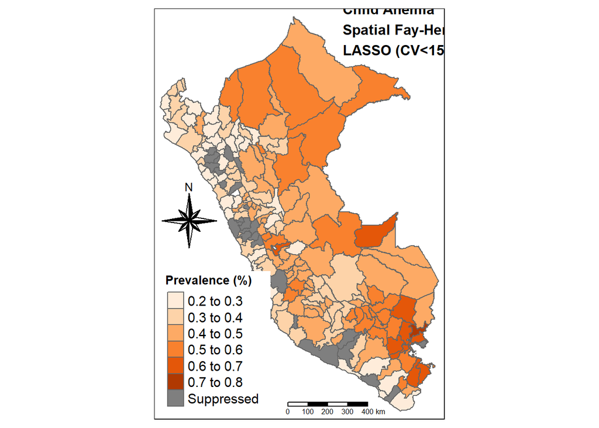

```r
# jpeg(paste(outputs, "map_lasso_CV15.jpg", sep="\\"),
#      width = 400, height = 500)
title = "Child Anemia \nSpatial Fay-Herriot \nLASSO (CV<15)"
choropleths(shp, mapdf_1, "ID_PROV", "lasso.estim", title)
```

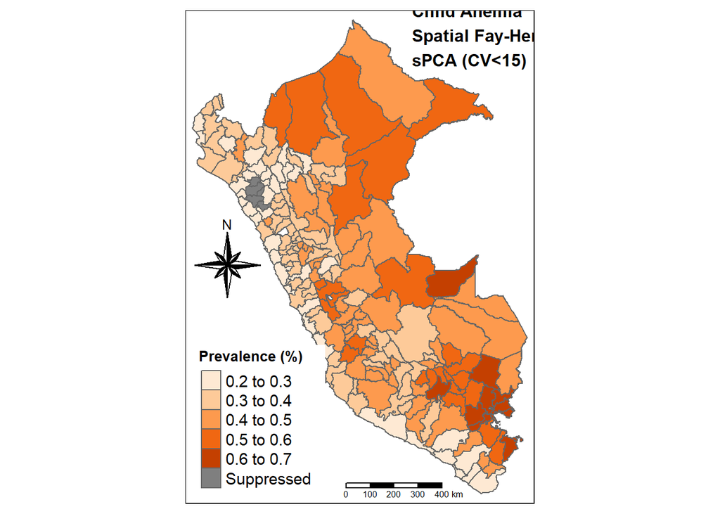

```r
# jpeg(paste(outputs, "map_sPCA_CV15.jpg", sep="\\"),
#      width = 400, height = 500)
title = "Child Anemia \nSpatial Fay-Herriot \nsPCA (CV<15)"
choropleths(shp, mapdf_1, "ID_PROV", "sPCA.estim", title)
```

## 8. Other diagnostics

### 8.1 Bechmarking of model estimates

We know that the DHS survey is representative at the subnational-1 level: regions. With this in mind, we can compute the share of children with anemia in each regions by the direct estimates and the SAE predictions. Ideally, the SAE predictions would not be statistically different from the direct estimates. We will prefer the model with the most similar population counts.

```r
bench.df <- compar.df[c("ID_PROV",
                        "dir.estim", "dir.se",
                        "expert.estim", "expert.mse",
                        "stepw.estim", "stepw.mse",
                        "lasso.estim", "lasso.mse",
                        "sPCA.estim", "sPCA.mse")]

bench.df$ID_PROV <- sprintf("%04d", bench.df$ID_PROV)
```

Load province population (children below 4 years)

```r
prov.pop <- read_excel(paste(data, "total_population",
                             "total_population_0-4y_provinces.xlsx", sep="\\"),
                       sheet = "Sheet1")
colnames(prov.pop) <- c("ID_PROV", "prov_pop")
prov.pop$ID_DPTO <- substring(prov.pop$ID_PROV, first=1, last=2)

prov.pop <- prov.pop %>%
            group_by(ID_DPTO) %>%
            mutate(dpto_pop = sum(prov_pop))

##shares
prov.pop$share.pop <- prov.pop$prov_pop/prov.pop$dpto_pop
#merge
bench.df <- merge(bench.df, prov.pop)
```

```r
#groupping at the regional level
bench.df$dir.prov.share <- bench.df$dir.estim*bench.df$share.pop
bench.df$expert.prov.share <- bench.df$expert.estim*bench.df$share.pop
bench.df$stepw.prov.share <- bench.df$stepw.estim*bench.df$share.pop
bench.df$lasso.prov.share <- bench.df$lasso.estim*bench.df$share.pop
bench.df$sPCA.prov.share <- bench.df$sPCA.estim*bench.df$share.pop

bench.df <- bench.df %>%
            group_by(ID_DPTO) %>%
            summarize(dir.dpto.share = sum(dir.prov.share),
                      expert.dpto.share = sum(expert.prov.share),
                      stepw.dpto.share = sum(stepw.prov.share),
                      lasso.dpto.share = sum(lasso.prov.share),
                      sPCA.dpto.share = sum(sPCA.prov.share))
```

```r
#direct estimates from survey

#erase the provinces not used in the provincial estimates
#Filter provinces. Drop vars with NA
endes <- endes %>%
          filter(!(endes$ID_PROV=="1608" |
                  endes$ID_PROV=="209"))

dpto.dir.svy <- svyby(~ANEMIA,
                        ~ID_DEP,
                        dclus2,
                        svymean,
                        na.rm=T)
colnames(dpto.dir.svy) <- c("ID_DPTO", "svy.estim", "svy.se")
bench.df <- merge(bench.df, dpto.dir.svy)

bench.df$lb <- bench.df$svy.estim - (1.96 * bench.df$svy.se)
bench.df$ub <- bench.df$svy.estim + (1.96 * bench.df$svy.se)

write_xlsx(bench.df, paste("04_results", "benchmarking.xls", sep="\\"))
```

### 8.2 Benchmarking of synthetic estimates

```r
synth.df <- data.frame(ID_PROV = prov.dir.svy$ID_PROV,
                        sample.size = nd_,

                        dir.estim = prov.dir.svy$ANEMIA,
                        dir.se = prov.dir.svy$se,

                        expert.estim = expert.model$SFH.synth,
                        stepw.estim = stepw.model$SFH.synth,
                        lasso.estim = lasso.model$SFH.synth,
                        sPCA.estim = sPCA.model$SFH.synth)

synth.df$ID_PROV <- sprintf("%04d", synth.df$ID_PROV)

synth.df <- merge(synth.df, prov.pop)
```

```r
#groupping at the regional level
synth.df$expert.prov.share <- synth.df$expert.estim*synth.df$share.pop
synth.df$stepw.prov.share <- synth.df$stepw.estim*synth.df$share.pop
synth.df$lasso.prov.share <- synth.df$lasso.estim*synth.df$share.pop
synth.df$sPCA.prov.share <- synth.df$sPCA.estim*synth.df$share.pop

synth.df <- synth.df %>%
            group_by(ID_DPTO) %>%
            summarize(expert.dpto.share = sum(expert.prov.share),
                      stepw.dpto.share = sum(stepw.prov.share),
                      lasso.dpto.share = sum(lasso.prov.share),
                      sPCA.dpto.share = sum(sPCA.prov.share))

synth.df <- merge(synth.df, dpto.dir.svy)

synth.df$lb <- synth.df$svy.estim - (1.96 * synth.df$svy.se)
synth.df$ub <- synth.df$svy.estim + (1.96 * synth.df$svy.se)

write_xlsx(synth.df, paste("04_results", "benchmarking_synth.xls", sep="\\"))
```

### 8.3 Total children in recovered provinces (non-suppressed with SAE)

```r
prov.pop2 <- transform(prov.pop,
                   ID_PROV = as.numeric(ID_PROV))
child.df <- merge(compar.df[c("ID_PROV", "dir.cv", "stepw.estim")],
                  prov.pop2[c("ID_PROV", "prov_pop")])
child.df$anemic.child <- child.df$stepw.estim * child.df$prov_pop

print(c("Total children in recovered provinces (CV>15)",
        round(sum(subset(child.df, dir.cv>15, "anemic.child")))))
```

```
## [1] "Total children in recovered provinces (CV>15)"
## [2] "32963"
```